# ASV Sharing Between Dogs

Yixuan Yang

# Set Up

```r
rm(list = ls())
set.seed(2024)
library(here)
library(phyloseq)
library(tidyverse)
library(gt)
theme_set(theme_bw())

ps.rarefied <- readRDS(here('data','following_study','ps_rarefied.rds'))
ps.rarefied
```

```
## phyloseq-class experiment-level object
## otu_table()   OTU Table:         [ 2548 taxa and 98 samples ]
## sample_data() Sample Data:       [ 98 samples by 28 sample variables ]
## tax_table()   Taxonomy Table:    [ 2548 taxa by 7 taxonomic ranks ]
## phy_tree()    Phylogenetic Tree: [ 2548 tips and 2547 internal nodes ]
## refseq()      DNAStringSet:      [ 2548 reference sequences ]
```

```r
sam <- data.frame(sample_data(ps.rarefied)) %>% rownames_to_column('Sample')
epi.dog <- sam %>% filter(Epileptic.or.Control == 'Epileptic')
ctl.dog <- sam %>% filter(Epileptic.or.Control == 'Control')
# double-check if data are paired
if (!identical(epi.dog$Household, ctl.dog$Household)) stop('data is not paired')
# dataset 1: orginal dataset
data1 <- list(epi.dog, ctl.dog)
```

# ASV Sharing between Dogs

In this section, we are trying to compare the ASV similarity between dogs from the same and different households.

To do this, we need two datasets:

1. the original dataset where each IE dog paired with a control dog from the same household.
2. a new dataset where each IE dog paired with a control dog that randomly selected from a different household.

## Breed Control

```r
sum(data1[[1]]$Predominant.Breed == data1[[2]]$Predominant.Breed)
```

```
## [1] 33
```

Most households (33/49) have dogs in same predominant breed. So, we need to control the breed effect when comparing ASV similarities.

Now, we want to pair each IE dog with a control dog that randomly selected from another household, and we will try to randomly select one (with replacement) that has the same predominate breed with the IE dog as possible.

```r
select.dog <- function(pair1, pair2) {
    diff.pair <- data.frame()
    map_dfr(1:nrow(pair1), function(i) {
      # for each dog in pair1, randomly select a dog from the different household
      sub.data <- filter(pair2, Household != pair1[i,'Household'])
      # if there's no dog in pair2 has same predominant breed as that is pair1,
      # randomly select a dog from a different household
      # else select one from the different household with the same predominate breed
      if (nrow(filter(sub.data, Predominant.Breed == pair1[i,'Predominant.Breed'])) == 0){
        selected <- sub.data %>%
          sample_n(1)
      } else {
        selected <- sub.data %>%
          filter(Predominant.Breed == pair1[i,'Predominant.Breed']) %>%
          sample_n(1)
      }
      return(selected)
    })
}

# dataset 2: paired dogs from different household
data2 <- list(epi.dog, select.dog(epi.dog, ctl.dog))

sum(data2[[1]]$Predominant.Breed == data2[[2]]$Predominant.Breed)
```

```
## [1] 31
```

Here, we can see with replacement, if we randomly select a dog from the control group and forcing the breed to be the same if possible, the pair with the same breed is at most 31 out of 49. Some of the households have dogs in same breed, but that breed has never appear in other households.

31 paired dogs from different households with same predominate breed is the best we can get. This is because some of the households have dogs with unique breed.

```r
unique.breed.household <- sapply(1:nrow(epi.dog), function(i) {
    # if breed in household is the same
    if (data1[[1]]$Predominant.Breed[i] == data1[[2]]$Predominant.Breed[i]) {
        # if the breed is not in the other households
        if(!(data1[[1]]$Predominant.Breed[i] %in% data1[[2]]$Predominant.Breed[-i])) {
            return(epi.dog[i,'Household'])
            }
        }
    }) %>% unlist
unique.breed.household
```

```
##  [1] "3"  "9"  "17" "19" "20" "21" "23" "25" "30" "48" "51"
```

By dropping two households (9 and 30), we can make sure that the breed effect is balanced.

```r
droped.household <- sample(unique.breed.household, 2); droped.household
```

```
## [1] "9"  "30"
```

```r
# regenerate the two dataset
sub.sam <- sam %>% filter(!(Household %in% droped.household))
epi.dog <- sub.sam %>% filter(Epileptic.or.Control == 'Epileptic')
ctl.dog <- sub.sam %>% filter(Epileptic.or.Control == 'Control')
# double-check if data are paired
if (!identical(epi.dog$Household, ctl.dog$Household)) stop('data is not paired')
data1 <- list(epi.dog, ctl.dog)
data2 <- list(epi.dog, select.dog(epi.dog, ctl.dog))

sum(data1[[1]]$Predominant.Breed == data1[[2]]$Predominant.Breed)
```

```
## [1] 31
```

```r
sum(data2[[1]]$Predominant.Breed == data2[[2]]$Predominant.Breed)
```

```
## [1] 31
```

# Compare Similarity

Now, we can calculate the Jaccard similarity between IE and control dogs for the two datasets.

```r
get.similarity <- function(ps, paired.data) {
    dissimilarities <- phyloseq::distance(ps, method = 'jaccard', binary = TRUE)
    dist <-  as.matrix(1 - dissimilarities)
    similarity <- dist[cbind(paired.data[[1]][,'Sample'], paired.data[[2]][,'Sample'])]
    return(similarity)
}

similarity <- data.frame(epi.dog,
                         same.house.sim = get.similarity(ps.rarefied, data1),
                         diff.house.sim = get.similarity(ps.rarefied, data2))
```

Visualize the similarity between dogs from same/different households. We can see dogs from the same households have higher ASV similarities.

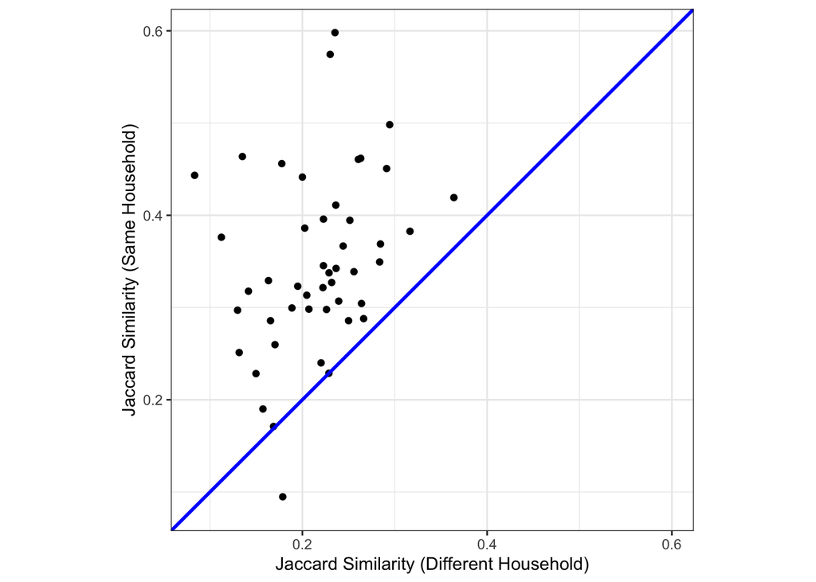

```r
similarity %>%
    ggplot() +
    geom_point(aes(x = diff.house.sim, y = same.house.sim)) +
    geom_abline(intercept = 0, slope = 1, color = "blue", linewidth = 1) +
    tune::coord_obs_pred() +
    labs(x = 'Jaccard Similarity (Different Household)', y = 'Jaccard Similarity (Same Household)')
```

```r
ggsave(here('figures','Figure2.png'), width = 170, units = "mm")
```

```
## Saving 170 x 127 mm image
```

```r
ggsave(here('figures','Figure2.pdf'), width = 170, units = "mm")
```

```
## Saving 170 x 127 mm image
```

Pairwise t test

```r
t.test(similarity$same.house.sim,
       similarity$diff.house.sim,
       paired = TRUE, alternative = 'greater')
```

```
##
##  Paired t-test
##
## data:  similarity$same.house.sim and similarity$diff.house.sim
## t = 9.2606, df = 46, p-value = 2.209e-12
## alternative hypothesis: true mean difference is greater than 0
## 95 percent confidence interval:
##  0.1078057       Inf
## sample estimates:
## mean difference
##       0.1316741
```

```r
similarity %>%
  select(same.house.sim, diff.house.sim) %>%
  summary()
```

```
##  same.house.sim    diff.house.sim
##  Min.   :0.09479   Min.   :0.08333
##  1st Qu.:0.29749   1st Qu.:0.17402
##  Median :0.33761   Median :0.22283
##  Mean   :0.34728   Mean   :0.21561
##  3rd Qu.:0.40343   3rd Qu.:0.25070
##  Max.   :0.59809   Max.   :0.36402
```

# ASV Sharing Rate

Check the frequency of sharing within a household for each ASV. The expected proportion for each ASV is $prevlance^2$. We can see most of the ASVs were shared within a household more often than expected by their study-wide prevalence.

```r
ASV.present <- ps.rarefied %>%
    transform_sample_counts(sign) %>%
    psmelt()

shared.rate <- ASV.present %>%
    group_by(Household, OTU) %>%
    summarise(shared = sum(Abundance) == 2) %>%
    group_by(OTU) %>%
    summarise(share.rate = sum(shared)/49) %>%
    arrange(str_rank(OTU, numeric = TRUE))
```

[output not shown]

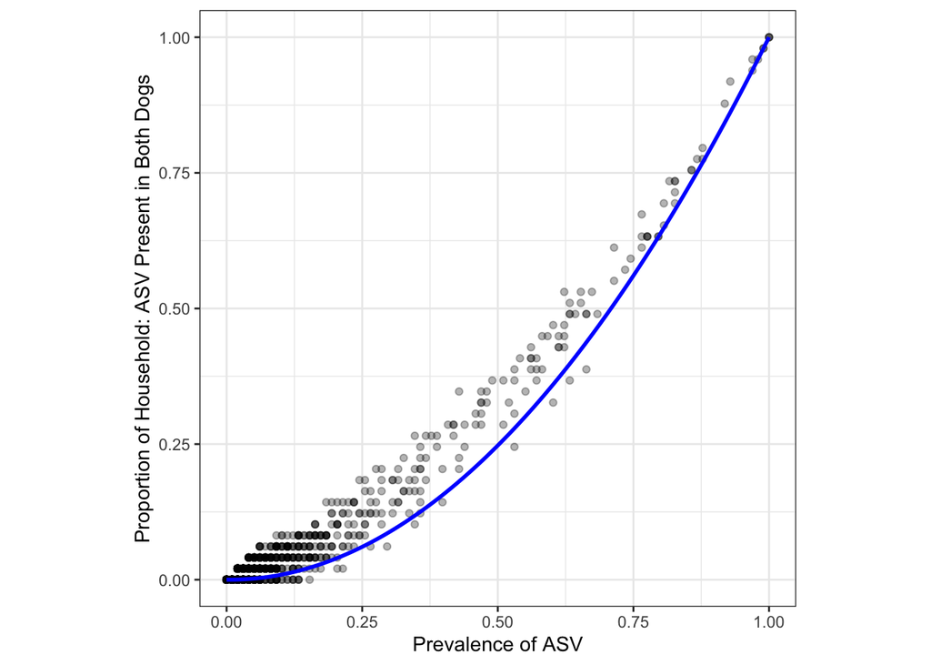

```r
prevalence <- ASV.present %>%
    group_by(OTU) %>%
    summarise(prevalence = sum(Abundance)/98) %>%
    arrange(str_rank(OTU, numeric = TRUE))

df <- prevalence %>%
    full_join(shared.rate, by = 'OTU')

ggplot(data = df) +
    geom_point(aes(x = prevalence, y = share.rate), alpha = 0.3) +
    stat_function(fun = function(x) x * (98*x-1)/97, color = "blue", linewidth = 1)  +
    coord_fixed() +
    labs(x = 'Prevalence of ASV', y = 'Proportion of Household: ASV Present in Both Dogs')
```

```r
ggsave(here('figures','Figure3.png'), width = 170, units = "mm")
```

```
## Saving 170 x 127 mm image
```

```r
ggsave(here('figures','Figure3.pdf'), width = 170, units = "mm")
```

```
## Saving 170 x 127 mm image
```

For ASVs with prevalence greater than 0.1, 286/322 of them were shared within a household than expected.

```r
shared.ASV <- df %>% rowwise() %>%
    mutate(fold.diff=(share.rate/prevalence^2)) %>%
    mutate(residual=(share.rate-prevalence^2)) %>%
    filter(prevalence > 0.1)

nrow(shared.ASV)
```

```
## [1] 322
```

```r
sum(shared.ASV$residual > 0)
```

```
## [1] 286
```

For more details…

```r
shared.ASV %>% head(20) %>% gt()
```

| OTU | prevalence | share.rate | fold.diff | residual |
| --- | --- | --- | --- | --- |
| ASV1 | 1.0000000 | 1.0000000 | 1.0000000 | 0.0000000000 |
| ASV2 | 0.9897959 | 0.9795918 | 0.9998937 | -0.0001041233 |
| ASV3 | 0.9693878 | 0.9591837 | 1.0207202 | 0.0194710537 |
| ASV4 | 1.0000000 | 1.0000000 | 1.0000000 | 0.0000000000 |
| ASV5 | 0.9285714 | 0.9183673 | 1.0650888 | 0.0561224490 |
| ASV6 | 1.0000000 | 1.0000000 | 1.0000000 | 0.0000000000 |
| ASV7 | 0.9897959 | 0.9795918 | 0.9998937 | -0.0001041233 |
| ASV8 | 0.6122449 | 0.4285714 | 1.1433333 | 0.0537276135 |
| ASV9 | 0.9795918 | 0.9591837 | 0.9995660 | -0.0004164931 |
| ASV10 | 0.8775510 | 0.7755102 | 1.0070308 | 0.0054144107 |
| ASV11 | 0.8673469 | 0.7755102 | 1.0308651 | 0.0232194919 |
| ASV12 | 0.3367347 | 0.1632653 | 1.4398531 | 0.0498750521 |
| ASV13 | 0.7755102 | 0.6326531 | 1.0519391 | 0.0312369846 |
| ASV14 | 0.6122449 | 0.4489796 | 1.1977778 | 0.0741357768 |
| ASV15 | 0.7142857 | 0.6122449 | 1.2000000 | 0.1020408163 |
| ASV16 | 0.6122449 | 0.4285714 | 1.1433333 | 0.0537276135 |
| ASV17 | 0.6326531 | 0.3673469 | 0.9177940 | -0.0329029571 |
| ASV18 | 0.8163265 | 0.7346939 | 1.1025000 | 0.0683048730 |
| ASV19 | 0.7448980 | 0.5918367 | 1.0666166 | 0.0369637651 |
| ASV20 | 0.8265306 | 0.7346939 | 1.0754458 | 0.0515410246 |